# Mixtures Workshop: Grouped Lasso

Lizzy Gibson

July 18, 2019

# Data Import and Cleaning

First, load the dataset; clean up names as needed; and convert factors to, well, factors.

Quick data descriptions; because of the length of the output, we don’t execute this command here, but encourage you to!

Next we remove missing values and reorder predictors (environmental variables first, confounders second). In keeping with standard practice, we’ll ln-transform the environmental exposures and the outcome. This is the dataset we’ll use to illustrate variable selection methods.

```
##  [1] "log_telomean" "lbx074la"     "lbx099la"     "lbx118la"     "lbx138la"
##  [6] "lbx153la"     "lbx170la"     "lbx180la"     "lbx187la"     "lbxd03la"
## [11] "lbxd05la"     "lbxd07la"     "lbxf03la"     "lbxf04la"     "lbxf05la"
## [16] "lbxf08la"     "lbxpcbla"     "lbxhxcla"     "lbx194la"     "lbxwbcsi"
## [21] "lbxlypct"     "lbxmopct"     "lbxnepct"     "lbxeopct"     "lbxbapct"
## [26] "bmi_cat3"     "edu_cat"      "race_cat"     "male"         "ln_lbxcot"
## [31] "age_cent"     "age_sq"
```

```
## [1] 1003   32
```

Model fitting methods aren’t “tidy-compliant” yet, so we’ll focus on creating the relevant matrices and vectors.

Let’s take a quick look at our design matrix.

```
## [1] 1003   36
```

```
##  [1] "lbx074la"  "lbx099la"  "lbx118la"  "lbx138la"  "lbx153la"  "lbx170la"
##  [7] "lbx180la"  "lbx187la"  "lbxd03la"  "lbxd05la"  "lbxd07la"  "lbxf03la"
## [13] "lbxf04la"  "lbxf05la"  "lbxf08la"  "lbxpcbla"  "lbxhxcla"  "lbx194la"
## [19] "lbxwbcsi"  "lbxlypct"  "lbxmopct"  "lbxnepct"  "lbxeopct"  "lbxbapct"
## [25] "bmi_cat32" "bmi_cat33" "edu_cat2"  "edu_cat3"  "edu_cat4"  "race_cat2"
## [31] "race_cat3" "race_cat4" "male1"     "ln_lbxcot" "age_cent"  "age_sq"
```

It’s helpful to note that chemical exposures appear in columns 1 to 18, and more traditional confounders appear in columns 19 to 36.

# Group definitions

First, 3 groups = 8 non-Dioxin-like PCBs, 2 non-ortho PCBs, and TEQ (3 dioxins, 4 furans, 1 mono-ortho (Dioxin-like) PCBs).

```
##                   group3
##  [1,] "lbx074la"  "2"
##  [2,] "lbx099la"  "2"
##  [3,] "lbx118la"  "4"
##  [4,] "lbx138la"  "2"
##  [5,] "lbx153la"  "2"
##  [6,] "lbx170la"  "2"
##  [7,] "lbx180la"  "2"
##  [8,] "lbx187la"  "2"
##  [9,] "lbxd03la"  "4"
## [10,] "lbxd05la"  "4"
## [11,] "lbxd07la"  "4"
## [12,] "lbxf03la"  "4"
## [13,] "lbxf04la"  "4"
## [14,] "lbxf05la"  "4"
```

[output cut: 22 more lines]

Second, 4 groups = 8 non-dioxin-like PCBs, 3 non-ortho PCBs, 3 dioxins, and 4 furans.

```
##                   group4
##  [1,] "lbx074la"  "4"
##  [2,] "lbx099la"  "4"
##  [3,] "lbx118la"  "5"
##  [4,] "lbx138la"  "4"
##  [5,] "lbx153la"  "4"
##  [6,] "lbx170la"  "4"
##  [7,] "lbx180la"  "4"
##  [8,] "lbx187la"  "4"
##  [9,] "lbxd03la"  "2"
## [10,] "lbxd05la"  "2"
## [11,] "lbxd07la"  "2"
## [12,] "lbxf03la"  "3"
## [13,] "lbxf04la"  "3"
## [14,] "lbxf05la"  "3"
```

[output cut: 22 more lines]

Third, 4 groups = 8 non-dioxin-like PCBs, 2 non-ortho PCBs, 1 mono-ortho PCB, and 3 dioxins and 4 furans (FD).

```
##                   group4b
##  [1,] "lbx074la"  "4"
##  [2,] "lbx099la"  "4"
##  [3,] "lbx118la"  "3"
##  [4,] "lbx138la"  "4"
##  [5,] "lbx153la"  "4"
##  [6,] "lbx170la"  "4"
##  [7,] "lbx180la"  "4"
##  [8,] "lbx187la"  "4"
##  [9,] "lbxd03la"  "2"
## [10,] "lbxd05la"  "2"
## [11,] "lbxd07la"  "2"
## [12,] "lbxf03la"  "2"
## [13,] "lbxf04la"  "2"
## [14,] "lbxf05la"  "2"
```

[output cut: 22 more lines]

# Grouped Variable Selection

The code chunk below fits a three-group model using group lasso, MCP, and SCAD penalties. MCP (minimax concave penalty) and SCAD (smoothly clipped absolute deviation) are other bias-reducing penalties. They try to give unbiased coefficients for covariates with large effects, but operate under the same general framework as group lasso.

Results are illustrated below.

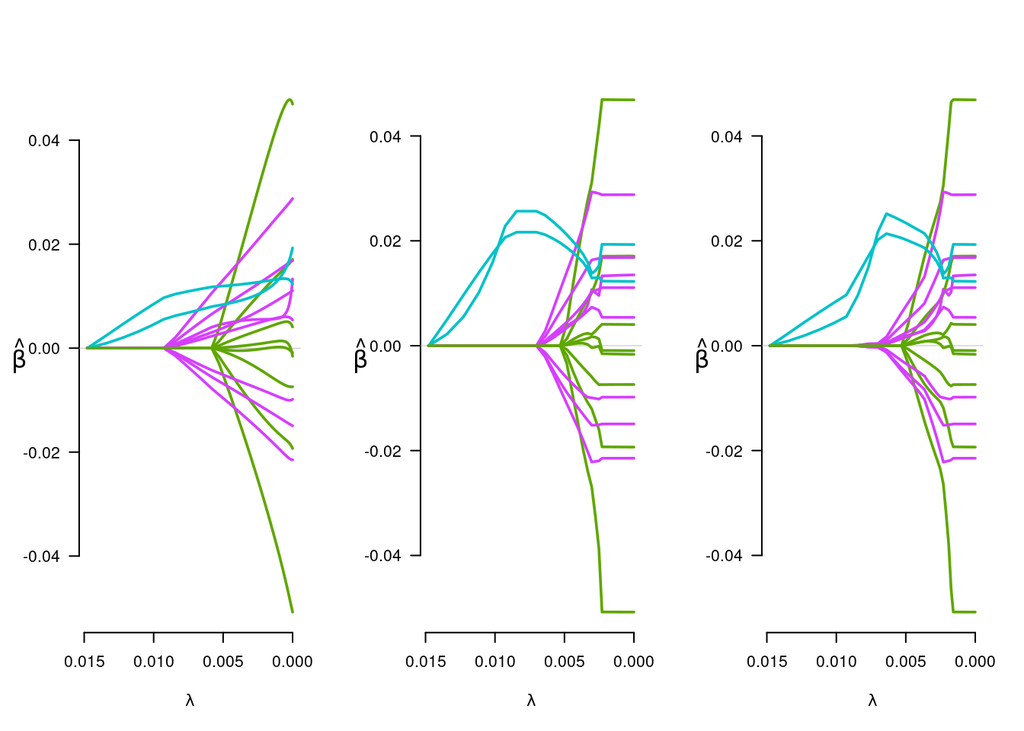

We repeat this process for the four-group categorization next.

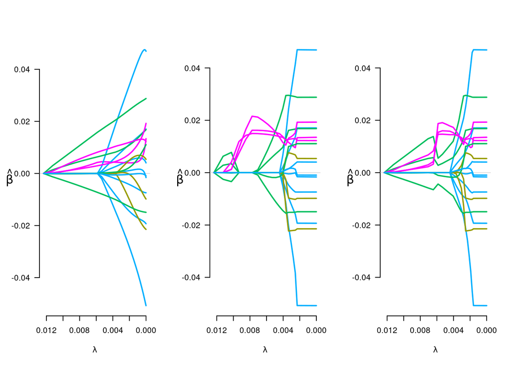

# Lasso w/ CV

As with `glmnet`, we can use CV to choose the tuning parameters. If not specified in code, ten-fold CV is the default.

We perform this analysis first with the three-group model and the lasso penalty.

```
##                     0.0044
## (Intercept)  0.29284662044
## lbx074la     0.00024311553
## lbx099la     0.00147645218
## lbx118la     0.00498773506
## lbx138la    -0.00510847005
## lbx153la     0.01211585768
## lbx170la     0.00413774462
## lbx180la    -0.00960636342
## lbx187la    -0.00123295991
## lbxd03la    -0.00573235126
## lbxd05la     0.00336729807
## lbxd07la    -0.01094828678
## lbxf03la     0.01488012721
## lbxf04la     0.00454948910
## lbxf05la    -0.00775574687
## lbxf08la     0.00900916018
## lbxpcbla     0.01208802240
## lbxhxcla     0.00870972702
## lbx194la    -0.00044790599
## lbxwbcsi    -0.00612561114
## lbxlypct    -0.00273523864
## lbxmopct    -0.00772621218
## lbxnepct    -0.00182516971
## lbxeopct    -0.00181189502
## lbxbapct     0.01619628197
## bmi_cat32   -0.00459380546
## bmi_cat33   -0.01856580776
## edu_cat2     0.01951231946
## edu_cat3     0.03620896508
## edu_cat4     0.01446338816
## race_cat2   -0.02718031879
## race_cat3    0.00990469991
## race_cat4   -0.03457376174
## male1       -0.04062701773
## ln_lbxcot    0.00357100728
## age_cent    -0.00614858673
## age_sq      -0.00001299552
```

```
## [1] 0.03919581
```

For completeness, we can repeat this with four groups.

```
##                      0.0059
## (Intercept)  0.118401653759
## lbx074la     0.000000000000
## lbx099la     0.000000000000
## lbx118la     0.004240296100
## lbx138la     0.000000000000
## lbx153la     0.000000000000
## lbx170la     0.000000000000
## lbx180la     0.000000000000
## lbx187la     0.000000000000
## lbxd03la     0.000000000000
## lbxd05la     0.000000000000
## lbxd07la     0.000000000000
## lbxf03la     0.015772614307
## lbxf04la     0.000085315107
## lbxf05la    -0.007248076006
## lbxf08la     0.006364831613
## lbxpcbla     0.008156695818
## lbxhxcla     0.002951331650
## lbx194la     0.000000000000
## lbxwbcsi    -0.006336362398
## lbxlypct    -0.001012349601
## lbxmopct    -0.006152687675
## lbxnepct    -0.000196253224
## lbxeopct     0.000016264214
## lbxbapct     0.018423453513
## bmi_cat32   -0.004909082693
## bmi_cat33   -0.017632903165
## edu_cat2     0.020454944811
## edu_cat3     0.037168265730
## edu_cat4     0.016170273272
## race_cat2   -0.032102584406
## race_cat3    0.006239683729
## race_cat4   -0.036959143360
## male1       -0.036808996434
## ln_lbxcot    0.003146172352
## age_cent    -0.006213668428
## age_sq      -0.000009318623
```

```
##                     0.0056
## (Intercept)  0.08733021560
## lbx074la     0.00000000000
## lbx099la     0.00000000000
## lbx118la     0.01202868136
## lbx138la     0.00000000000
## lbx153la     0.00000000000
## lbx170la     0.00000000000
## lbx180la     0.00000000000
## lbx187la     0.00000000000
## lbxd03la    -0.00359014979
## lbxd05la     0.00288391182
## lbxd07la    -0.00790001132
## lbxf03la     0.01223725022
## lbxf04la     0.00366393224
## lbxf05la    -0.00552297842
## lbxf08la     0.00620725684
## lbxpcbla     0.00820932472
## lbxhxcla     0.00541514385
## lbx194la     0.00000000000
## lbxwbcsi    -0.00626732676
## lbxlypct    -0.00103848653
## lbxmopct    -0.00615056660
## lbxnepct    -0.00019090522
## lbxeopct    -0.00015378045
## lbxbapct     0.01825953824
## bmi_cat32   -0.00462480445
## bmi_cat33   -0.01869578569
## edu_cat2     0.01951552163
## edu_cat3     0.03564130745
## edu_cat4     0.01483519552
## race_cat2   -0.02906603149
## race_cat3    0.00733588951
## race_cat4   -0.03572818204
## male1       -0.03795722230
## ln_lbxcot    0.00349850251
## age_cent    -0.00627230707
## age_sq      -0.00001168978
```

## Data Visualization

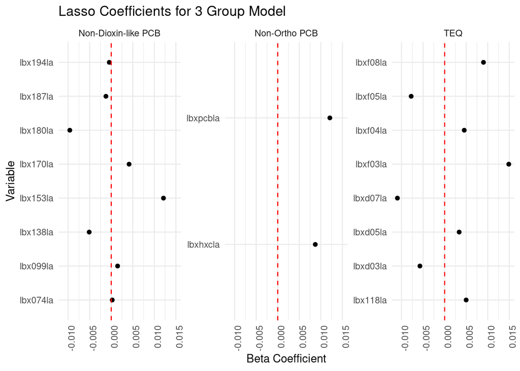

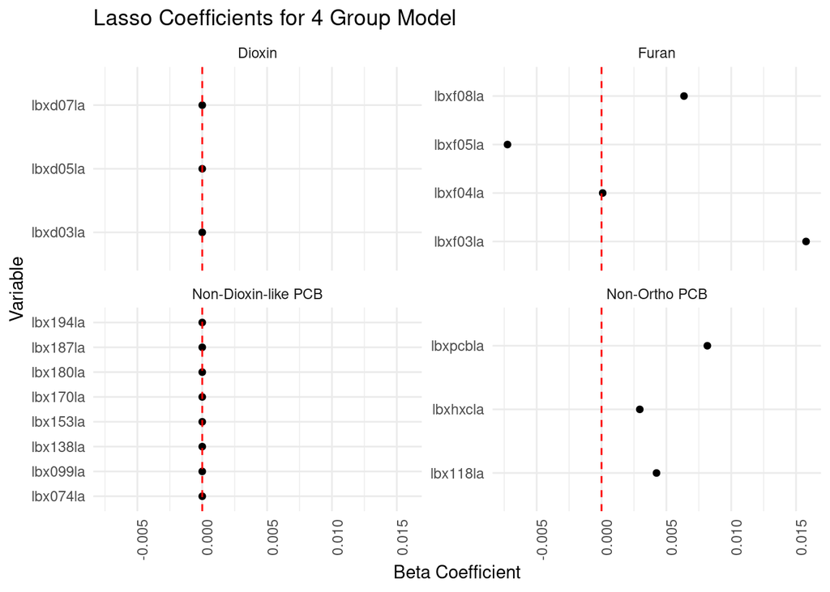

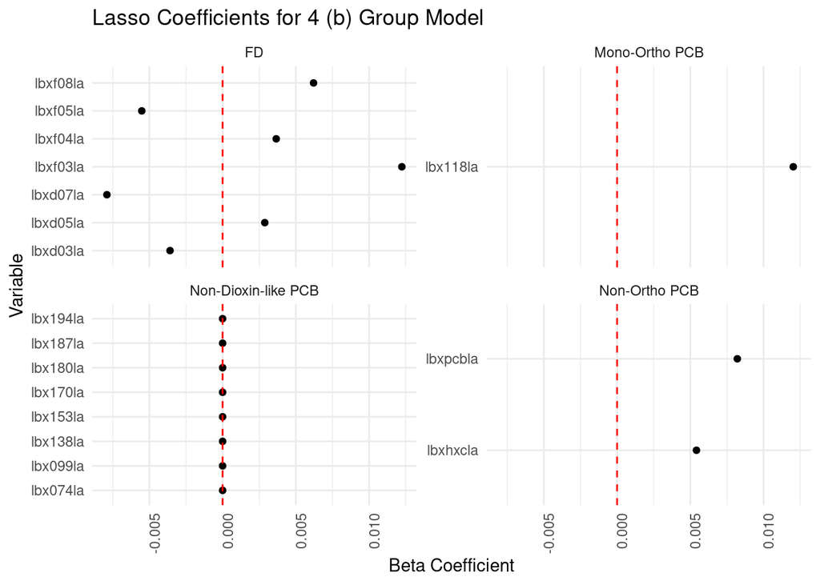

# MCP w/ CV

We repeat the previous analyses, substituting the MCP penalty for the lasso.

```
##                      0.0064
## (Intercept)  0.615101021036
## lbx074la     0.000000000000
## lbx099la     0.000000000000
## lbx118la     0.000657793451
## lbx138la     0.000000000000
## lbx153la     0.000000000000
## lbx170la     0.000000000000
## lbx180la     0.000000000000
## lbx187la     0.000000000000
## lbxd03la    -0.001267752714
## lbxd05la     0.000552906991
## lbxd07la    -0.002075089172
## lbxf03la     0.002756968589
## lbxf04la     0.000898117439
## lbxf05la    -0.001927616251
## lbxf08la     0.001700490578
## lbxpcbla     0.021181823339
## lbxhxcla     0.024860861348
## lbx194la     0.000000000000
## lbxwbcsi    -0.006139352520
## lbxlypct    -0.006406975728
## lbxmopct    -0.011164153144
## lbxnepct    -0.005474537814
## lbxeopct    -0.005587294669
## lbxbapct     0.012842087679
## bmi_cat32   -0.000810764269
## bmi_cat33   -0.016799929986
## edu_cat2     0.016258522610
## edu_cat3     0.033286816311
## edu_cat4     0.012949339407
## race_cat2   -0.024954774691
## race_cat3    0.007696422989
## race_cat4   -0.034081921392
## male1       -0.042251583196
## ln_lbxcot    0.003555098411
## age_cent    -0.006868218108
## age_sq      -0.000005567769
```

```
##                      0.0049
## (Intercept)  0.103312378061
## lbx074la     0.000000000000
## lbx099la     0.000000000000
## lbx118la     0.015327029081
## lbx138la     0.000000000000
## lbx153la     0.000000000000
## lbx170la     0.000000000000
## lbx180la     0.000000000000
## lbx187la     0.000000000000
## lbxd03la     0.000000000000
## lbxd05la     0.000000000000
## lbxd07la     0.000000000000
## lbxf03la     0.016336981624
## lbxf04la    -0.001857421628
## lbxf05la    -0.011277233309
## lbxf08la     0.007281575565
## lbxpcbla     0.014101693942
## lbxhxcla     0.015307530104
## lbx194la     0.000000000000
## lbxwbcsi    -0.006086701362
## lbxlypct    -0.002391549706
## lbxmopct    -0.007559746455
## lbxnepct    -0.001495694975
## lbxeopct    -0.001358915780
## lbxbapct     0.016204030415
## bmi_cat32   -0.002484250603
## bmi_cat33   -0.017930761232
## edu_cat2     0.017592778500
## edu_cat3     0.034043328719
## edu_cat4     0.012608275052
## race_cat2   -0.024471462791
## race_cat3    0.004169172142
## race_cat4   -0.034874605168
## male1       -0.035409428016
## ln_lbxcot    0.003607231775
## age_cent    -0.007013054973
## age_sq      -0.000009220213
```

## Data Visualization

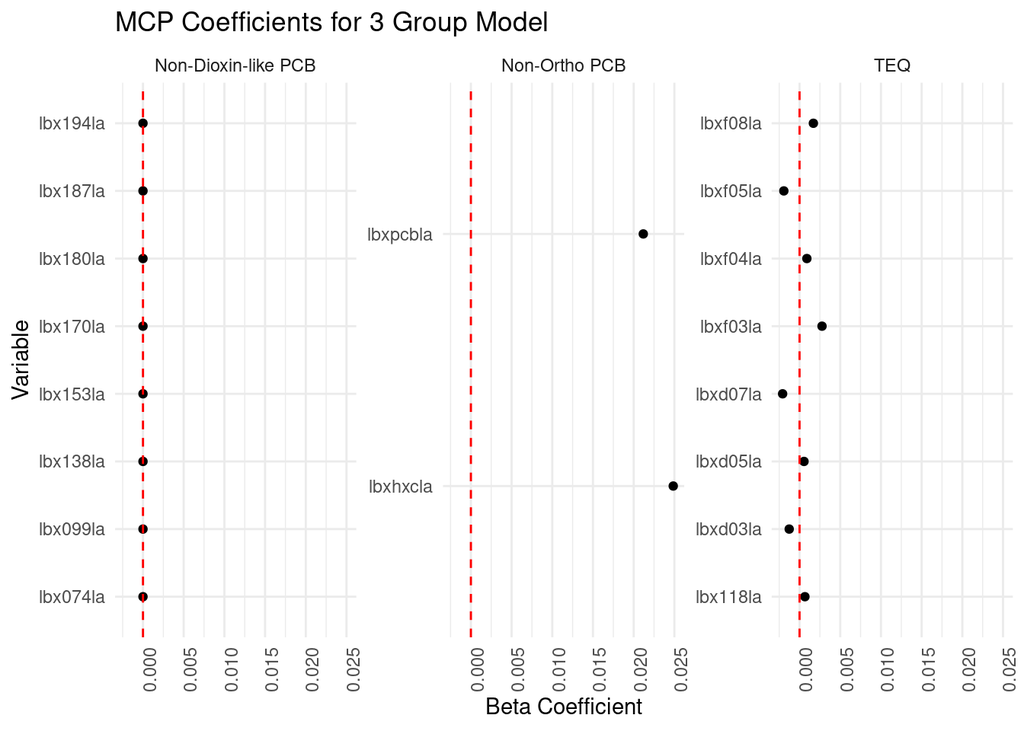

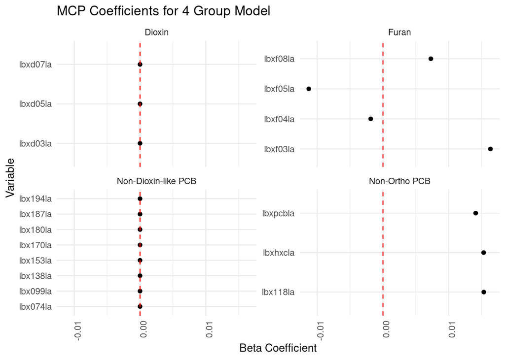

# SCAD w/ CV

```
##                      0.0044
## (Intercept)  0.660421232703
## lbx074la     0.000434174802
## lbx099la     0.001029253909
## lbx118la     0.002278975832
## lbx138la    -0.003915205214
## lbx153la     0.008789835779
## lbx170la     0.002761594198
## lbx180la    -0.007316827269
## lbx187la    -0.001409843213
## lbxd03la    -0.004425180707
## lbxd05la     0.002208038262
## lbxd07la    -0.007625510696
## lbxf03la     0.009879800502
## lbxf04la     0.003281861613
## lbxf05la    -0.006499180546
## lbxf08la     0.006076311073
## lbxpcbla     0.019564511113
## lbxhxcla     0.022534828971
## lbx194la     0.000452873305
## lbxwbcsi    -0.006017381140
## lbxlypct    -0.006800311369
## lbxmopct    -0.011637595736
## lbxnepct    -0.005832914086
## lbxeopct    -0.005916893336
## lbxbapct     0.012023679128
## bmi_cat32   -0.001653708109
## bmi_cat33   -0.017123210990
## edu_cat2     0.016971448426
## edu_cat3     0.033959512988
## edu_cat4     0.012585557335
## race_cat2   -0.023674904965
## race_cat3    0.009130371241
## race_cat4   -0.033727699731
## male1       -0.042656927983
## ln_lbxcot    0.003695356648
## age_cent    -0.006683952207
## age_sq      -0.000009486443
```

```
##                      0.0078
## (Intercept)  0.149750113285
## lbx074la     0.000000000000
## lbx099la     0.000000000000
## lbx118la     0.002351636485
## lbx138la     0.000000000000
## lbx153la     0.000000000000
## lbx170la     0.000000000000
## lbx180la     0.000000000000
## lbx187la     0.000000000000
## lbxd03la     0.000000000000
## lbxd05la     0.000000000000
## lbxd07la     0.000000000000
## lbxf03la     0.011281141132
## lbxf04la    -0.000071588043
## lbxf05la    -0.005052492305
## lbxf08la     0.004809958645
## lbxpcbla     0.005893234819
## lbxhxcla     0.001898235330
## lbx194la     0.000000000000
## lbxwbcsi    -0.006457850307
## lbxlypct    -0.000959125483
## lbxmopct    -0.005986181484
## lbxnepct    -0.000188163909
## lbxeopct    -0.000010728032
## lbxbapct     0.018784641478
## bmi_cat32   -0.004981353493
## bmi_cat33   -0.017116678634
## edu_cat2     0.020886781321
## edu_cat3     0.037591942875
## edu_cat4     0.016785685741
## race_cat2   -0.034043603588
## race_cat3    0.007046661834
## race_cat4   -0.037171916287
## male1       -0.037732730061
## ln_lbxcot    0.002996452705
## age_cent    -0.006002913760
## age_sq      -0.000008800147
```

## Data Visualization

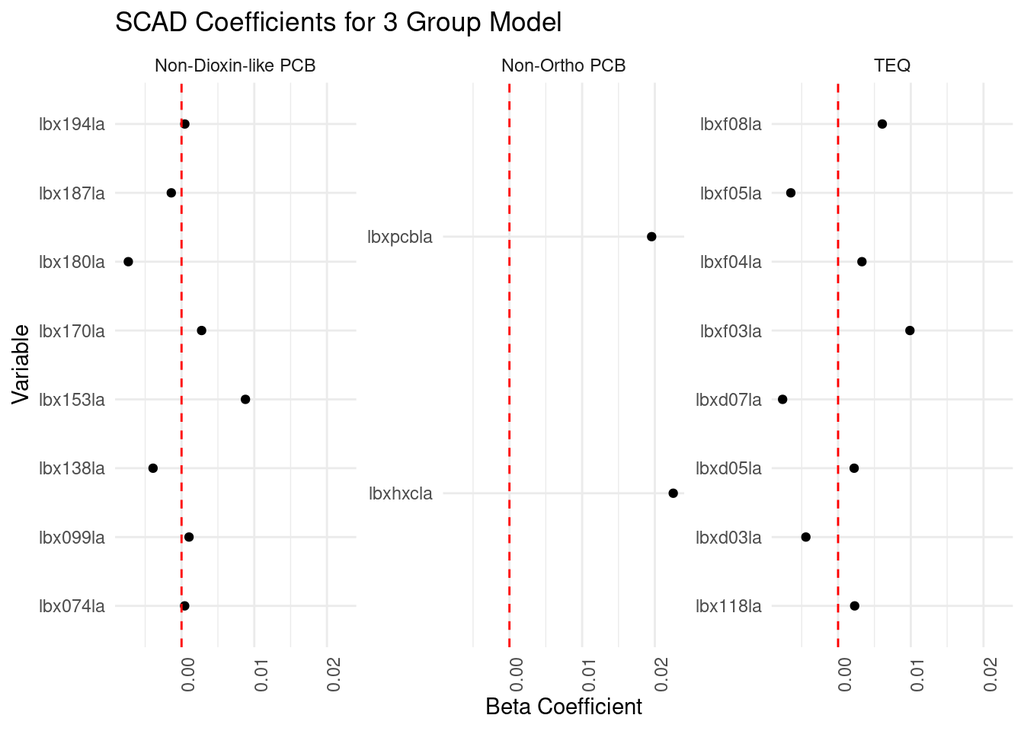

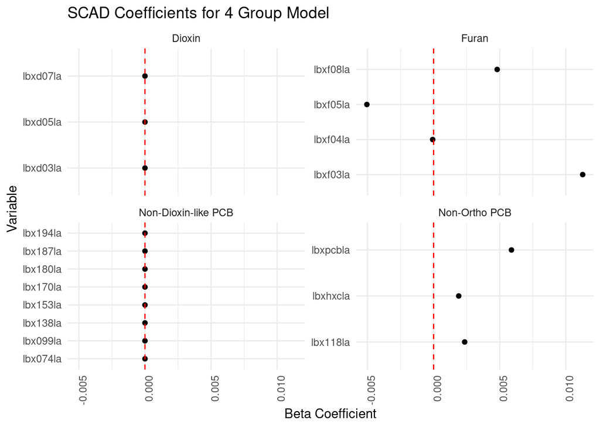

## OLS from MCP Results

Lastly, we compare the results for MCP (with four groups) with the results from the corresponding OLS fit.

```
## # A tibble: 25 × 3
##    term          mcp      ols
##    <chr>       <dbl>    <dbl>
##  1 lbx118la  0.0153  -0.0378
##  2 lbxf03la  0.0163  NA
##  3 lbxf04la -0.00186 NA
##  4 lbxf05la -0.0113  NA
##  5 lbxf08la  0.00728 NA
##  6 lbxpcbla  0.0141   0.0256
##  7 lbxhxcla  0.0153  -0.0560
##  8 lbxwbcsi -0.00609 -0.00130
##  9 lbxlypct -0.00239 -0.00396
## 10 lbxmopct -0.00756 -0.0119
## # … with 15 more rows
```

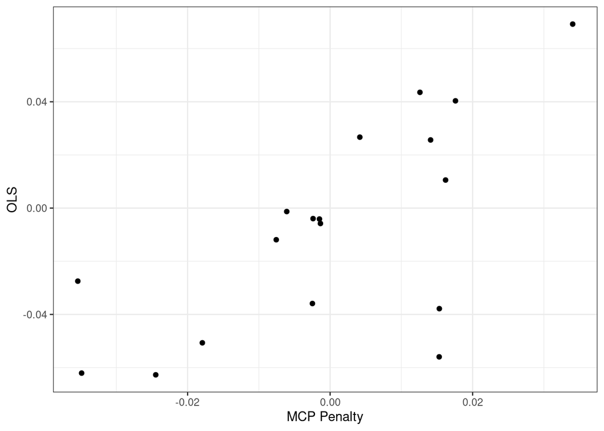